# Lecture 13 - Theory and Homework

This is an [R Markdown](http://rmarkdown.rstudio.com) Notebook

### Lecture 13 - What Data and Manipulation Data

#### We can review the data first…

Pay attention to the column names in those tables. Are some of them common?

```r
library(tidyverse)
# data frame containing information from multiple sensors
read_csv("DF_Data.csv") %>% head(6)
```

| RowNumber | StartDateTime | EventCode | IDEquipment | TimeTotal |
| --- | --- | --- | --- | --- |
| 1 | 2016-11-17 05:08:07 | 103007090 | 3 | 69 |
| 2 | 2016-11-17 06:23:02 | 103007090 | 3 | 51 |
| 3 | 2016-11-17 07:08:19 | 103007090 | 3 | 76 |
| 4 | 2016-11-17 14:20:52 | 103007090 | 3 | 136 |
| 5 | 2016-11-17 14:23:08 | 103007080 | 3 | 4 |
| 6 | 2016-11-17 14:48:27 | 103007300 | 3 | 273 |

```r
# data frame containing equipment information
read_csv("DF_EquipmData.csv") %>% head(3)
```

| IDEquipment | Name |
| --- | --- |
| 3 | Machine #1 |
| 13 | Machine #2 |
| 23 | Machine #3 |

```r
# data frame containing Event Names
read_csv("DF_EvCodeData.csv") %>% head(3)
```

| EventCode | EventText |
| --- | --- |
| 103007050 | Step 1 SubStep 1 |
| 103007070 | Step 1 SubStep 2 |
| 103007080 | Step 1 SubStep 3 |

#### Manipulate data

Run the code from the App directly

```r
# data frame containing equipment information
DF_Equipm <- read_csv("DF_EquipmData.csv")
# data frame containing Event Names
DF_EvCode <- read_csv("DF_EvCodeData.csv")
```

```r
# Data manipulation and saving to the DF_TEMP
DF_TEMP <- read_csv("DF_Data.csv") %>%
  # arrange by date
  arrange(StartDateTime) %>%
  # join to decode equipment serial number
  inner_join(DF_Equipm, by = "IDEquipment") %>%
  # select only column needed
  select(StartDateTime, Name, EventCode, TimeTotal) %>%
  # join to decode Event Code meaning
  inner_join(DF_EvCode, by = "EventCode") %>%
  # select only column needed
  select(StartDateTime, Name, EventCode, TimeTotal, EventText)
# =================================
#
head(DF_TEMP)
```

| StartDateTime | Name | EventCode | TimeTotal | EventText |
| --- | --- | --- | --- | --- |
| 2016-10-25 00:14:40 | Machine #1 | 103007090 | 58 | Step 1 SubStep 4 |
| 2016-10-25 01:06:16 | Machine #1 | 103007090 | 95 | Step 1 SubStep 4 |
| 2016-10-25 02:30:32 | Machine #1 | 103007090 | 485 | Step 1 SubStep 4 |
| 2016-10-25 04:50:16 | Machine #1 | 103007090 | 130 | Step 1 SubStep 4 |
| 2016-10-25 07:19:06 | Machine #1 | 103007090 | 270 | Step 1 SubStep 4 |
| 2016-10-25 07:23:36 | Machine #1 | 103007080 | 5 | Step 1 SubStep 3 |

As you see we have now Start Time, Name of the Machine, time total and event text. This is definitely will not be easy to comprehend by human eye as is. However as you will see this structure is good for creating visualizations using data graphic grammar of ggplot2

#### Data manipulation step by step

Let’s review how did we get this step by step… in particular, notice using the construct `%>%` called `pipe`. It is passing the **result** from the calculations to the first argument of the next function. Last function we will use `head()` is just to reduce the output for our `R Notebook`

```r
# read data and arrange by start date time and ouput only 6 rows...
read_csv("DF_Data.csv") %>%
  # arrange by date
  arrange(StartDateTime) %>% head()
```

| RowNumber | StartDateTime | EventCode | IDEquipment | TimeTotal |
| --- | --- | --- | --- | --- |
| 186 | 2016-10-25 00:14:40 | 103007090 | 3 | 58 |
| 187 | 2016-10-25 01:06:16 | 103007090 | 3 | 95 |
| 188 | 2016-10-25 02:30:32 | 103007090 | 3 | 485 |
| 189 | 2016-10-25 04:50:16 | 103007090 | 3 | 130 |
| 190 | 2016-10-25 07:19:06 | 103007090 | 3 | 270 |
| 191 | 2016-10-25 07:23:36 | 103007080 | 3 | 5 |

Now we ‘join’ the IDEquipment table … notice that Column **Name** will be added with all information we need to understand what machine number it is representing in reality…

```r
read_csv("DF_Data.csv") %>%
  # arrange by date
  arrange(StartDateTime) %>%
  # join to decode equipment serial number
  inner_join(DF_Equipm, by = "IDEquipment") %>% head()
```

| RowNumber | StartDateTime | EventCode | IDEquipment | TimeTotal | Name |
| --- | --- | --- | --- | --- | --- |
| 186 | 2016-10-25 00:14:40 | 103007090 | 3 | 58 | Machine #1 |
| 187 | 2016-10-25 01:06:16 | 103007090 | 3 | 95 | Machine #1 |
| 188 | 2016-10-25 02:30:32 | 103007090 | 3 | 485 | Machine #1 |
| 189 | 2016-10-25 04:50:16 | 103007090 | 3 | 130 | Machine #1 |
| 190 | 2016-10-25 07:19:06 | 103007090 | 3 | 270 | Machine #1 |
| 191 | 2016-10-25 07:23:36 | 103007080 | 3 | 5 | Machine #1 |

Now we will repeat exact same for Event Code…

```r
read_csv("DF_Data.csv") %>%
  # arrange by date
  arrange(StartDateTime) %>%
  # join to decode equipment serial number
  inner_join(DF_Equipm, by = "IDEquipment") %>%
  # select only column needed
  select(StartDateTime, Name, EventCode, TimeTotal) %>%
  # join to decode Event Code meaning
  inner_join(DF_EvCode, by = "EventCode") %>% head()
```

| StartDateTime | Name | EventCode | TimeTotal | EventText |
| --- | --- | --- | --- | --- |
| 2016-10-25 00:14:40 | Machine #1 | 103007090 | 58 | Step 1 SubStep 4 |
| 2016-10-25 01:06:16 | Machine #1 | 103007090 | 95 | Step 1 SubStep 4 |
| 2016-10-25 02:30:32 | Machine #1 | 103007090 | 485 | Step 1 SubStep 4 |
| 2016-10-25 04:50:16 | Machine #1 | 103007090 | 130 | Step 1 SubStep 4 |
| 2016-10-25 07:19:06 | Machine #1 | 103007090 | 270 | Step 1 SubStep 4 |
| 2016-10-25 07:23:36 | Machine #1 | 103007080 | 5 | Step 1 SubStep 3 |

now we will select only columns we will need…

```r
read_csv("DF_Data.csv") %>%
  # arrange by date
  arrange(StartDateTime) %>%
  # join to decode equipment serial number
  inner_join(DF_Equipm, by = "IDEquipment") %>%
  # select only column needed
  select(StartDateTime, Name, EventCode, TimeTotal) %>%
  # join to decode Event Code meaning
  inner_join(DF_EvCode, by = "EventCode") %>%
  # select only column needed
  select(StartDateTime, TimeTotal, Name, EventText) %>% head()
```

| StartDateTime | TimeTotal | Name | EventText |
| --- | --- | --- | --- |
| 2016-10-25 00:14:40 | 58 | Machine #1 | Step 1 SubStep 4 |
| 2016-10-25 01:06:16 | 95 | Machine #1 | Step 1 SubStep 4 |
| 2016-10-25 02:30:32 | 485 | Machine #1 | Step 1 SubStep 4 |
| 2016-10-25 04:50:16 | 130 | Machine #1 | Step 1 SubStep 4 |
| 2016-10-25 07:19:06 | 270 | Machine #1 | Step 1 SubStep 4 |
| 2016-10-25 07:23:36 | 5 | Machine #1 | Step 1 SubStep 3 |

This way we have prepared our data for visualization

#### Visualisation with facets

This code snippet would plot our data:

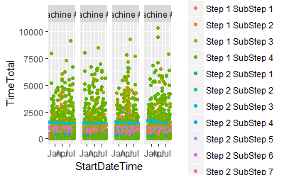

```r
read_csv("DF_Data.csv") %>%
  # join to decode equipment serial number
  inner_join(DF_Equipm, by = "IDEquipment") %>%
  # select only column needed
  select(StartDateTime, Name, EventCode, TimeTotal) %>%
  # join to decode Event Code meaning
  inner_join(DF_EvCode, by = "EventCode") %>%
  # select only column needed
  select(StartDateTime, TimeTotal, Name, EventText) %>%
  # arrange by date
  arrange(StartDateTime) %>%
  # make a plot
  ggplot(aes(x = StartDateTime, y = TimeTotal, col = EventText)) + geom_point()+
  facet_grid(.~Name)
```

Seems like it’s hard to get some good understanding on what is going on, isn’t it?